# Applications sur données réelles - Planctons - TP 2

Outils de surveillance et analyses statistiques

INTECHMER - CT3 GEM

## Données Planctons

Nous disposons de données de concentrations de planctons dans l’océan, provenant d’une étude [1] de 2008 à 2019, entre 0 et 500m de profondeur. Les données sont disponibles sur le site [SEANOE](https://www.seanoe.org/data/00846/95809/) ou en téléchargeant ce fichier

Voici le jeu de données une fois importé :

```r
library(tidyverse)

data = read_csv("103673.csv", show_col_types = FALSE)
```

|  | psampleid | lat | lon | datetime | day_night | prod | layer | Acantharea | Actinopterygii | Annelida | Appendicularia | Cephalopoda | Chaetognatha | Cnidaria_others | Collodaria | Collodaria_colonial | Copepoda | Crustacea_others | Ctenophora | Doliolida | Eumalacostraca | Foraminifera | Gymnosomata | Hydrozoa_others | Limacinidae | Mollusca_others | Narcomedusae | Nostocales | Ostracoda | … |
| --- | --- | --- | --- | --- | --- | --- | --- | --- | --- | --- | --- | --- | --- | --- | --- | --- | --- | --- | --- | --- | --- | --- | --- | --- | --- | --- | --- | --- | --- | --- |
| 1 | 16315 | 38.96217 | 14.32367 | 2008-06-19T08:13:37Z | day | False | epi | 0.00401959625260596 | 0 | 0.0002641833432402087 | 0 | 0 | 0 | 0.00204536126866223 | 0.00309495455126523 | 0.00147102088849661 | 0.0050404631251646 | 0 | 0 | 0 | 0 | 0.00335208298114824 | 0 | 0 | 0 | 0 | 0 | 0 | 0 | … |
| 2 | 16317 | 34.3285 | 19.81933 | 2008-06-21T00:16:09Z | night | False | epi | 0 | 0 | 0.0006366385484641094 | 0 | 0 | 0 | 0 | 0.00466040696694077 | 0.0006366385484641094 | 0.00232511469873848 | 0 | 0 | 0 | 0 | 0.0003498644275343304 | 0 | 0 | 0 | 0 | 0 | 0 | 0 | … |
| 3 | 16320 | 34.3305 | 19.81867 | 2008-06-21T03:54:43Z | day | False | epi | 0 | 0 | 0 | 0 | 0 | 0 | 0 | 0.00227744788841796 | 0 | 0.000574481530418797 | 0.00112463605762466 | 0 | 0 | 0.0005411782532930697 | 0.00160806203408724 | 0 | 0 | 0 | 0 | 0 | 0 | 0 | … |
| 4 | 16321 | 34.25967 | 20.9845 | 2008-06-21T10:39:18Z | day | False | epi | 0 | 0 | 0 | 0 | 0 | 0 | 0 | 0.00147102088849661 | 0 | 0 | 0 | 0 | 0 | 0.00190367409099562 | 0.0001618122977346278 | 0 | 0 | 0 | 0 | 0 | 0 | 0 | … |
| 5 | 16325 | 34.18383 | 22.1635 | 2008-06-21T19:41:42Z | night | False | epi | 0 | 0 | 0.0009407691728757432 | 0.0007097030602395958 | 0 | 0 | 0 | 0.00125435889716765 | 0.0008607037113544034 | 0.00431939385525663 | 0 | 0 | 0.02694764643080955 | 0 | 0.0003135897242919144 | 0 | 0 | 0 | 0 | 0 | 0 | 0 | … |
| 6 | 16328 | 34.18517 | 22.161 | 2008-06-21T22:56:04Z | night | False | epi | 0 | 0 | 0.0009193880553103854 | 0 | 0 | 0 | 0 | 0.00188255649420697 | 0.0006856453293840162 | 0.00559363456089005 | 0.00460470696606948 | 0 | 0.0027804955553883 | 0.0025671836751355 | 0.0008989572096368212 | 0 | 0 | 0 | 0 | 0 | 0 | 0 | … |
| 7 | 16330 | 34.11667 | 23.32667 | 2008-06-22T05:51:28Z | day | False | epi | 0 | 0 | 0 | 0 | 0 | 0 | 0 | 0 | 0 | 0 | 0 | 0 | 0 | 0 | 0 | 0 | 0 | 0 | 0 | 0 | 0 | 0 | … |
| 8 | 16333 | 34.04533 | 24.49633 | 2008-06-22T13:47:23Z | day | False | epi | 0 | 0 | 0.0004639779146512626 | 0 | 0 | 0 | 0 | 0.00102758938027479 | 0.0004994206720204563 | 0.0012171014862591 | 0 | 0 | 0 | 0 | 0.00181302294380535 | 0 | 0 | 0 | 0 | 0 | 0 | 0 | … |
| 9 | 16335 | 34.046 | 24.49733 | 2008-06-22T16:56:17Z | day | False | epi | 0 | 0 | 0 | 0 | 0 | 0.0007650699656483586 | 0 | 0.00337789981802926 | 0.0007650699656483586 | 0 | 0 | 0 | 0 | 0 | 0.00348686432828827 | 0 | 0 | 0 | 0 | 0 | 0 | 0 | … |
| 10 | 16336 | 33.9735 | 25.6685 | 2008-06-22T23:35:33Z | night | False | epi | 0 | 0 | 0 | 0 | 0 | 0.00196931802516788 | 0 | 0.00206501641666605 | 0.00154106950223455 | 0.00172706064905596 | 0 | 0 | 0 | 0.0009299557341070564 | 0 | 0 | 0 | 0 | 0 | 0 | 0 | 0 | … |

[output cut: 4254 more lines]

Dans ces variables, nous avons différents types de variables :

- Variables contextuelles : identifiant (`psampleid`), coordonnées (`lat` et `lon`), temps (`date`, `day_night`) et informations supplémentaires (`prod` et `layer`) ;
- Variables de concentrations de planctons : de `Acantharea` à `Trichodesmium` ;
- Variables potentiellement explicatives des concentrations : de `temp` à `kd490`.

### Quelques codes utiles pour le TP

#### Sélection des variables de concentrations

Il est possible de ne sélectionner que les variables de concentrations de la façon suivante :

```r
data_conc = data %>%
  select(Acantharea:Trichodesmium)
```

|  | Acantharea | Actinopterygii | Annelida | Appendicularia | Cephalopoda | Chaetognatha | Cnidaria_others | Collodaria | Collodaria_colonial | Copepoda | Crustacea_others | Ctenophora | Doliolida | Eumalacostraca | Foraminifera | Gymnosomata | Hydrozoa_others | Limacinidae | Mollusca_others | Narcomedusae | Nostocales | Ostracoda | Phaeodaria | Pyrosoma | Salpida | Siphonophorae | Thecosomata | Trichodesmium |
| --- | --- | --- | --- | --- | --- | --- | --- | --- | --- | --- | --- | --- | --- | --- | --- | --- | --- | --- | --- | --- | --- | --- | --- | --- | --- | --- | --- | --- |
| 1 | 0.00401959625260596 | 0 | 0.0002641833432402087 | 0 | 0 | 0 | 0.00204536126866223 | 0.00309495455126523 | 0.00147102088849661 | 0.0050404631251646 | 0 | 0 | 0 | 0 | 0.00335208298114824 | 0 | 0 | 0 | 0 | 0 | 0 | 0 | 0.00170185801253762 | 0 | 0 | 0 | 0 | 0 |
| 2 | 0 | 0 | 0.0006366385484641094 | 0 | 0 | 0 | 0 | 0.00466040696694077 | 0.0006366385484641094 | 0.00232511469873848 | 0 | 0 | 0 | 0 | 0.0003498644275343304 | 0 | 0 | 0 | 0 | 0 | 0 | 0 | 0 | 0 | 0 | 0 | 0 | 0 |
| 3 | 0 | 0 | 0 | 0 | 0 | 0 | 0 | 0.00227744788841796 | 0 | 0.000574481530418797 | 0.00112463605762466 | 0 | 0 | 0.0005411782532930697 | 0.00160806203408724 | 0 | 0 | 0 | 0 | 0 | 0 | 0 | 0.000574481530418797 | 0 | 0 | 0 | 0 | 0 |
| 4 | 0 | 0 | 0 | 0 | 0 | 0 | 0 | 0.00147102088849661 | 0 | 0 | 0 | 0 | 0 | 0.00190367409099562 | 0.0001618122977346278 | 0 | 0 | 0 | 0 | 0 | 0 | 0 | 0 | 0 | 0 | 0 | 0 | 0 |
| 5 | 0 | 0 | 0.0009407691728757432 | 0.0007097030602395958 | 0 | 0 | 0 | 0.00125435889716765 | 0.0008607037113544034 | 0.00431939385525663 | 0 | 0 | 0.02694764643080955 | 0 | 0.0003135897242919144 | 0 | 0 | 0 | 0 | 0 | 0 | 0 | 0.0003135897242919144 | 0 | 0.0007097030602395958 | 0 | 0 | 0 |
| 6 | 0 | 0 | 0.0009193880553103854 | 0 | 0 | 0 | 0 | 0.00188255649420697 | 0.0006856453293840162 | 0.00559363456089005 | 0.00460470696606948 | 0 | 0.0027804955553883 | 0.0025671836751355 | 0.0008989572096368212 | 0 | 0 | 0 | 0 | 0 | 0 | 0 | 0 | 0 | 0 | 0.0009407691728757432 | 0 | 0 |
| 7 | 0 | 0 | 0 | 0 | 0 | 0 | 0 | 0 | 0 | 0 | 0 | 0 | 0 | 0 | 0 | 0 | 0 | 0 | 0 | 0 | 0 | 0 | 0 | 0 | 0 | 0 | 0 | 0 |
| 8 | 0 | 0 | 0.0004639779146512626 | 0 | 0 | 0 | 0 | 0.00102758938027479 | 0.0004994206720204563 | 0.0012171014862591 | 0 | 0 | 0 | 0 | 0.00181302294380535 | 0 | 0 | 0 | 0 | 0 | 0 | 0 | 0 | 0 | 0 | 0 | 0 | 0 |
| 9 | 0 | 0 | 0 | 0 | 0 | 0.0007650699656483586 | 0 | 0.00337789981802926 | 0.0007650699656483586 | 0 | 0 | 0 | 0 | 0 | 0.00348686432828827 | 0 | 0 | 0 | 0 | 0 | 0 | 0 | 0.00108964510259008 | 0 | 0 | 0 | 0 | 0 |
| 10 | 0 | 0 | 0 | 0 | 0 | 0.00196931802516788 | 0 | 0.00206501641666605 | 0.00154106950223455 | 0.00172706064905596 | 0 | 0 | 0 | 0.0009299557341070564 | 0 | 0 | 0 | 0 | 0 | 0 | 0 | 0 | 0 | 0 | 0 | 0 | 0 | 0 |

[output cut: 4254 more lines]

#### Transformation des concentrations via fonction `decostand()`

Dans l’exemple ci-dessous, on divise chaque ligne par le total de la ligne.

```r
library(vegan)

data_total = decostand(data_conc, method = "total")
```

|  | Acantharea | Actinopterygii | Annelida | Appendicularia | Cephalopoda | Chaetognatha | Cnidaria_others | Collodaria | Collodaria_colonial | Copepoda | Crustacea_others | Ctenophora | Doliolida | Eumalacostraca | Foraminifera | Gymnosomata | Hydrozoa_others | Limacinidae | Mollusca_others | Narcomedusae | Nostocales | Ostracoda | Phaeodaria | Pyrosoma | Salpida | Siphonophorae | Thecosomata | Trichodesmium |
| --- | --- | --- | --- | --- | --- | --- | --- | --- | --- | --- | --- | --- | --- | --- | --- | --- | --- | --- | --- | --- | --- | --- | --- | --- | --- | --- | --- | --- |
| 1 | 0.1915049115737886 | 0 | 0.01258644018132027 | 0 | 0 | 0 | 0.09744678427284084 | 0.1474523709391677 | 0.07008358737326024 | 0.2401418909796696 | 0 | 0 | 0 | 0 | 0.1597026951342729 | 0 | 0 | 0 | 0 | 0 | 0 | 0 | 0.08108131954567971 | 0 | 0 | 0 | 0 | 0 |
| 2 | 0 | 0 | 0.07395324156637413 | 0 | 0 | 0 | 0 | 0.5413624466430084 | 0.07395324156637413 | 0.2700900996337134 | 0 | 0 | 0 | 0 | 0.04064097059052994 | 0 | 0 | 0 | 0 | 0 | 0 | 0 | 0 | 0 | 0 | 0 | 0 | 0 |
| 3 | 0 | 0 | 0 | 0 | 0 | 0 | 0 | 0.3399030203329976 | 0 | 0.0857398355009193 | 0.1678489306851103 | 0 | 0 | 0.08076941025448921 | 0.2399989677255643 | 0 | 0 | 0 | 0 | 0 | 0 | 0 | 0.0857398355009193 | 0 | 0 | 0 | 0 | 0 |
| 4 | 0 | 0 | 0 | 0 | 0 | 0 | 0 | 0.4159530217763632 | 0 | 0 | 0 | 0 | 0 | 0.5382921458282367 | 0.04575483239540015 | 0 | 0 | 0 | 0 | 0 | 0 | 0 | 0 | 0 | 0 | 0 | 0 | 0 |
| 5 | 0 | 0 | 0.02586701133345741 | 0.01951371030418717 | 0 | 0 | 0 | 0.03448934844460968 | 0.02366556356039721 | 0.1187643186330754 | 0 | 0 | 0.740941663197781 | 0 | 0.008622337111152472 | 0 | 0 | 0 | 0 | 0 | 0 | 0 | 0.008622337111152472 | 0 | 0.01951371030418717 | 0 | 0 | 0 |
| 6 | 0 | 0 | 0.04404605044598454 | 0 | 0 | 0 | 0 | 0.09018953186558692 | 0.03284790202751389 | 0.2679798901261434 | 0.220602338854621 | 0 | 0.1332080037260469 | 0.1229886564285984 | 0.04306724932496266 | 0 | 0 | 0 | 0 | 0 | 0 | 0 | 0 | 0 | 0 | 0.04507037720054231 | 0 | 0 |
| 7 | 0 | 0 | 0 | 0 | 0 | 0 | 0 | 0 | 0 | 0 | 0 | 0 | 0 | 0 | 0 | 0 | 0 | 0 | 0 | 0 | 0 | 0 | 0 | 0 | 0 | 0 | 0 | 0 |
| 8 | 0 | 0 | 0.09240540301935209 | 0 | 0 | 0 | 0 | 0.2046537298958909 | 0.09946414908333037 | 0.242396781833371 | 0 | 0 | 0 | 0 | 0.3610799361680557 | 0 | 0 | 0 | 0 | 0 | 0 | 0 | 0 | 0 | 0 | 0 | 0 | 0 |
| 9 | 0 | 0 | 0 | 0 | 0 | 0.08066487411390877 | 0 | 0.3561476411635296 | 0.08066487411390877 | 0 | 0 | 0 | 0 | 0 | 0.3676362747494501 | 0 | 0 | 0 | 0 | 0 | 0 | 0 | 0.1148863358592027 | 0 | 0 | 0 | 0 | 0 |
| 10 | 0 | 0 | 0 | 0 | 0 | 0.2392149509973026 | 0 | 0.2508395264798755 | 0.1871951918121752 | 0.2097877149619203 | 0 | 0 | 0 | 0.1129626157487265 | 0 | 0 | 0 | 0 | 0 | 0 | 0 | 0 | 0 | 0 | 0 | 0 | 0 | 0 |

[output cut: 4254 more lines]

#### Carte des points de collecte

On peut représenter les points de collecte de données sur une carte à l’aide du code suivant :

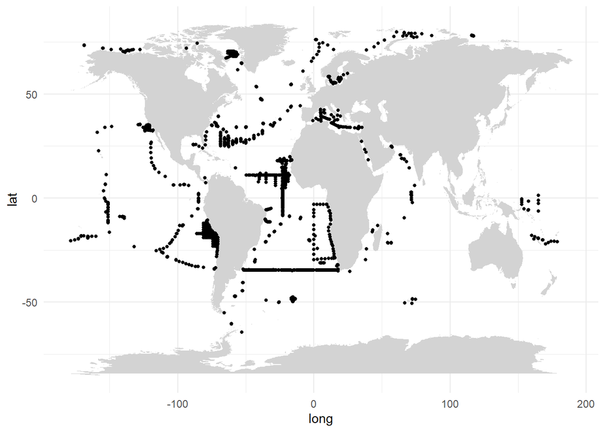

```r
library(maps)
library(ggplot2)
ggplot() +
  geom_polygon(data = map_data("world"),
               aes(x = long, y = lat, group = group),
               fill = "lightgray") +
  geom_point(data = data, aes(x = lon, y = lat), size = 1) +
  theme_minimal()
```

## A faire

Nous souhaitons donc étudier les concentrations de planctons pour avoir des profils type. Pour cela, nous allons procéder aux étapes suivantes en suivant le plan de l’article initial, **pour chaque couche** (cf variable `layer`) :

### En considérant les données brutes

1. Décrire succinctement les données, en particulier de concentrations
2. Effectuer une transformation de Hellinger sur les données de concentrations (cf fonction `decostand()` du package `vegan` par exemple - le paramètre `method` doit égal à `"hellinger"`)
3. Faire quelques traitements sur les autres variables explicatives
   - Remplacer les données manquantes par la valeur moyenne de la variable
   - Transformer les variables `bulk_conc` et `snow_conc` en calculant $\log(1+x)$ (car valeurs parfois égales à 0)
   - Normaliser toutes ces variables
4. Réaliser une ACP sur les concentrations, en ajoutant les variables explicatives en variables supplémentaires (cf paramètre `quanti.sup` dans la fonction `PCA()`)
5. Rechercher un nombre de classes avec une CAH (en utilisant la distance euclidienne et la méthode de *Ward*)
6. Rechercher la partition optimale à l’aide de $k$-means
7. Décrire les classes à partir des données de concentrations
   - Représenter la partition sur le plan factoriel
   - Représenter les variables supplémentaires
8. Représenter la partition sur une carte

Dans l’article initial [1], la partition est recherchée sur les cinq premiers facteurs de l’ACP. L’idée n’est pas nouvelle et elle est couramment mise en oeuvre. L’idée derrière est de supprimer le *bruit* éventuel présent dans les données. Essayez de comparer vos résultats avec leurs résultats.

### En binarisant les variables

1. Effectuer une transformation binaire sur les données de concentrations (toujours avec la fonction `descostand()`, avec le paramètre `method` égal à `"pa"` - *presence/absence*)
2. Rechercher une partition à l’aide de la CAH, en utilisant la distance de Manhattan (cf paramètre `method` dans la fonction `dist()`) et le lien simple (cf paramètre `method` dans la fonction `hclust()`)
3. Décrire les classes ainsi obtenues, en utilisant les variables d’origine
4. Comparer cette partition avec celle obtenue précédemment

## Bibliographie

1. Panaïotis, T., Babin, M., Biard, T., Carlotti, F., Coppola, L., Guidi, L., Hauss, H., Karp-Boss, L., Kiko, R., Lombard, F., McDonnell, A. M. P., Picheral, M., Rogge, A., Waite, A. M., Stemmann, L., & Irisson, J.-O. (2023). Three major mesoplanktonic communities resolved by in situ imaging in the upper 500 m of the global ocean. *Global Ecology and Biogeography*, 32, 1991–2005. https://doi.org/10.1111/geb.13741